### Mercedes-Benz Greener Manufacturing : Solution Notebook

### Import Section

```python
import numpy as np
import pandas as pd
import seaborn as sns
import matplotlib.pyplot as plt
from subprocess import check_output
%matplotlib inline
import plotly.offline as py
py.init_notebook_mode(connected=True)
import plotly.graph_objs as go
import plotly.tools as tls
import os
import gc
import pandas as pd
import matplotlib.pyplot as plt
import re
import time
import warnings
import numpy as np
from nltk.corpus import stopwords
from sklearn.decomposition import TruncatedSVD
```

```python
from sklearn.decomposition import TruncatedSVD
from sklearn.preprocessing import normalize
from sklearn.feature_extraction.text import CountVectorizer
from sklearn.manifold import TSNE
import seaborn as sns
from sklearn.neighbors import KNeighborsClassifier
from sklearn.metrics import confusion_matrix
from sklearn.metrics.classification import accuracy_score, log_loss
from sklearn.feature_extraction.text import TfidfVectorizer
from sklearn.linear_model import SGDClassifier
from collections import Counter
from scipy.sparse import hstack
from sklearn.multiclass import OneVsRestClassifier
from sklearn.svm import SVC
from collections import Counter, defaultdict
from sklearn.calibration import CalibratedClassifierCV
from sklearn.naive_bayes import MultinomialNB
from sklearn.naive_bayes import GaussianNB
from sklearn.model_selection import train_test_split
from sklearn.model_selection import GridSearchCV
import math
from sklearn.metrics import normalized_mutual_info_score
from sklearn.ensemble import RandomForestClassifier
warnings.filterwarnings("ignore")
from sklearn import model_selection
from sklearn.linear_model import LogisticRegression
from scipy import stats
from sklearn.feature_extraction.text import CountVectorizer
from sklearn.preprocessing import LabelBinarizer
from sklearn.preprocessing import LabelEncoder
from sklearn.preprocessing import Normalizer
import string
import matplotlib.pyplot as plt
import seaborn as sns
import matplotlib.cm as cm
from scipy.stats import randint as sp_randint
from scipy.stats import uniform
from sklearn.preprocessing import StandardScaler,MinMaxScaler
from sklearn.model_selection import RandomizedSearchCV,GridSearchCV
from sklearn.ensemble import RandomForestRegressor
import xgboost as xgb
#from prettytable import PrettyTable
import pickle
from sklearn.model_selection import RepeatedKFold,KFold
from sklearn.metrics import r2_score
from sklearn.preprocessing import LabelEncoder
from sklearn.decomposition import PCA
from sklearn.feature_extraction import DictVectorizer
from xgboost import plot_importance
#from mlxtend.regressor import StackingCVRegressor
from sklearn.linear_model import Ridge
from sklearn.ensemble import ExtraTreesRegressor
from sklearn.model_selection import cross_val_score
from sklearn.linear_model import SGDRegressor
from scipy import stats
import random
from sklearn.feature_selection import SelectKBest
from sklearn.feature_selection import f_regression
from sklearn.svm import SVR
from sklearn.decomposition import TruncatedSVD, PCA
from sklearn.model_selection import cross_validate
```

### Reading Train CSV

```python
train_df = pd.read_csv('train.csv')
print("Number of data points:",train_df.shape[0])
```

```
Number of data points: 4209
```

```python
train_df.info()
```

```
<class 'pandas.core.frame.DataFrame'>
RangeIndex: 4209 entries, 0 to 4208
Columns: 378 entries, ID to X385
dtypes: float64(1), int64(369), object(8)
memory usage: 12.1+ MB
```

### Checking whether there are any rows with null values

```python
##Checking whether there are any rows with null values
nan_rows = train_df[train_df.isnull().any(1)]
print (nan_rows)
```

```
Empty DataFrame
Columns: [ID, y, X0, X1, X2, X3, X4, X5, X6, X8, X10, X11, X12, X13, X14, X15, X16, X17, X18, X19, X20, X21, X22, X23, X24, X26, X27, X28, X29, X30, X31, X32, X33, X34, X35, X36, X37, X38, X39, X40, X41, X42, X43, X44, X45, X46, X47, X48, X49, X50, X51, X52, X53, X54, X55, X56, X57, X58, X59, X60, X…
Index: []

[0 rows x 378 columns]
```

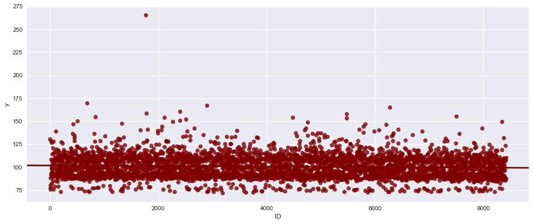

```python
sns.set(rc={'figure.figsize':(15,6)})
sns.regplot(x='ID', y='y', data=train_df,color='maroon')
```

[output not shown]

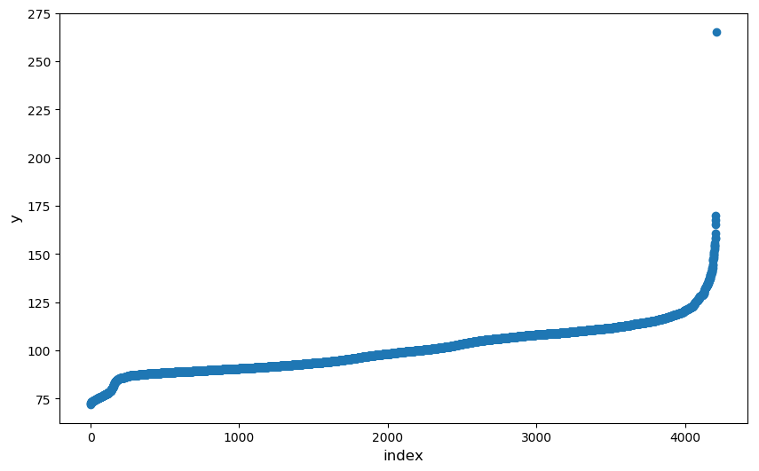

```python
plt.style.use('default')
plt.figure(figsize=(10,6))
plt.scatter(range(train_df.shape[0]), np.sort(train_df.y.values))
plt.xlabel('index',fontsize=12)
plt.ylabel('y', fontsize=12)
```

From the above plot it is clear that there are some outliers. Let's look into it further.

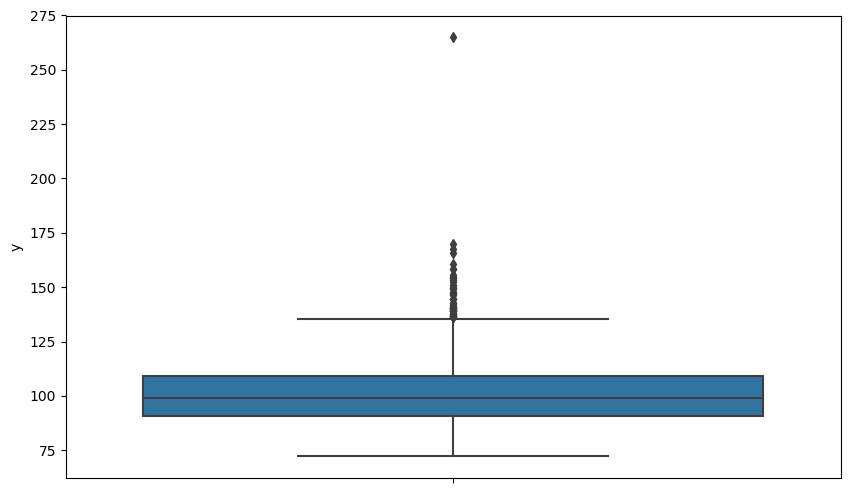

```python
# the skewed box plot shows us the presence of outliers
plt.figure(figsize=(10,6))
sns.boxplot(y=train_df['y'], data =train_df)
plt.show()
```

From the above plot we can say most points above 140 might be outliers. So, we can set 150 as a threshold value. But, before doing that lets look furthur.

```python
#calculating 0-100th percentile to find a the correct percentile value for removal of outliers
for i in range(0,100,10):
    var =train_df['y'].values
    var = np.sort(var,axis = None)
print("{} percentile value is {}".format(i,var[int(len(var)*(float(i)/100))]))
print ("100 percentile value is ",var[-1])
```

```
90 percentile value is 115.25
100 percentile value is  265.32
```

```python
#looking further from the 90th percecntile
for i in range(90,100):
    var =train_df['y'].values
    var = np.sort(var,axis = None)
print("{} percentile value is {}".format(i,var[int(len(var)*(float(i)/100))]))
print ("100 percentile value is ",var[-1])
```

```
99 percentile value is 137.44
100 percentile value is  265.32
```

We can clearly see that the 99th percentile value is 137.44 and 100th percentile value is 265.32, which is an outlier point. Let's look furthur.

```python
from franges import frange
#looking further from the 99th percecntile
for i in frange(99, 100, 0.1):
    var =train_df['y'].values
    var = np.sort(var,axis = None)
print("{} percentile value is {}".format(i,var[int(len(var)*(float(i)/100))]))
print ("100 percentile value is ",var[-1])
```

```
99.9 percentile value is 160.87
100 percentile value is  265.32
```

Taking 150 as threshold, will remove everything that is above 150 as outliers.

```python
#removing data based on our analysis
train_df_modified=train_df[train_df.y<150]
```

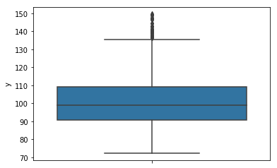

```python
#box-plot after removal of outliers
sns.boxplot(y=train_df_modified['y'], data =train_df_modified)
plt.show()
```

From the above plot we can see that some outliers have been removed. Now lets check for duplicate features

```python
rem_cols=[]
#removing duplicate columns and leaving the original behind.
dups=list(train_df_modified.T.index[train_df_modified.T.duplicated(keep= 'first')].values)
print(dups)
rem_cols.extend(dups)
```

```
['X35', 'X37', 'X39', 'X76', 'X84', 'X93', 'X94', 'X102', 'X107', 'X113', 'X119', 'X122', 'X134', 'X146', 'X147', 'X172', 'X199', 'X213', 'X214', 'X216', 'X222', 'X226', 'X227', 'X232', 'X233', 'X235', 'X239', 'X242', 'X243', 'X244', 'X245', 'X247', 'X248', 'X253', 'X254', 'X262', 'X266', 'X268', 'X…
```

```python
# Found to have really low variance so will remove it
train_df_modified.X4.value_counts()
```

```
d    4190
a       2
c       1
b       1
Name: X4, dtype: int64
```

```python
df_num = train_df_modified.loc[:,train_df_modified.dtypes==np.int64]
```

### Removing features with variance is equal to zero

```python
#Removing features with 0 variance
temp = []
for i in df_num.columns:
    if train_df_modified[i].var()==0:
        temp.append(i)
print(len(temp))
print(temp)
```

```
13
['X11', 'X93', 'X107', 'X233', 'X235', 'X268', 'X289', 'X290', 'X293', 'X297', 'X330', 'X339', 'X347']
```

```python
rem_cols.extend(temp)
rem_cols= list(set(rem_cols))
rem_cols.append('X4')#Dropping X4 as it has very low variance
train_df_modified= train_df_modified.drop(rem_cols,axis=1)
train_df_modified.shape
```

```
(4194, 319)
```

```python
print("Number of data points:",train_df_modified.shape[0])
```

```
Number of data points: 4194
```

```python
print("Number of data points removed:",train_df.shape[0]-train_df_modified.shape[0])
```

```
Number of data points removed: 15
```

```python
print("Number of features removed:",train_df.shape[1]-train_df_modified.shape[1])
```

```
Number of features removed: 59
```

```python
Y_train = train_df_modified['y']
```

```python
train_df_modified.drop(['y'],axis=1,inplace=True)
X_train = train_df_modified
```

```python
train_df_modified.shape
```

```
(4194, 318)
```

```python
X_train_cat = X_train.loc[:,X_train.dtypes==np.object]
```

```python
X_train_cat.shape
```

```
(4194, 7)
```

```python
X_train_cat.head(2)
```

|  | X0 | X1 | X2 | X3 | X5 | X6 | X8 |
| --- | --- | --- | --- | --- | --- | --- | --- |
| 0 | k | v | at | a | u | j | o |
| 1 | k | t | av | e | y | l | o |

```python
X_train_num = X_train.loc[:,X_train.dtypes==np.int64]
```

```python
X_train_num.head(2)
```

|  | ID | X10 | X12 | X13 | X14 | X15 | X16 | X17 | X18 | X19 | ... | X373 | X374 | X375 | X376 | X377 | X378 | X379 | X380 | X383 | X384 |
| --- | --- | --- | --- | --- | --- | --- | --- | --- | --- | --- | --- | --- | --- | --- | --- | --- | --- | --- | --- | --- | --- |
| 0 | 0 | 0 | 0 | 1 | 0 | 0 | 0 | 0 | 1 | 0 | ... | 0 | 0 | 0 | 0 | 1 | 0 | 0 | 0 | 0 | 0 |
| 1 | 6 | 0 | 0 | 0 | 0 | 0 | 0 | 0 | 1 | 0 | ... | 0 | 0 | 1 | 0 | 0 | 0 | 0 | 0 | 0 | 0 |

2 rows × 311 columns

Lets try plotting TSNE on numerical features: t-Distributed Stochastic Neighbor Embedding (t-SNE)

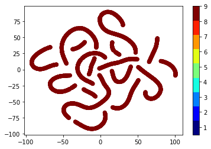

```python
xtsne=TSNE(perplexity=20)
results=xtsne.fit_transform(X_train_num)
vis_x = results[:, 0]
vis_y = results[:, 1]
plt.scatter(vis_x, vis_y, c=Y_train, cmap=plt.cm.get_cmap("jet", 9))
plt.colorbar(ticks=range(10))
plt.clim(0.5, 9)
plt.show()
```

The above plot seems to tell that some points can be easily separated. Lets try PCA

```python
standardized_data = StandardScaler().fit_transform(X_train_num)
print(standardized_data.shape)
pca = PCA()
pca.n_components = 2
pca_data = pca.fit_transform(standardized_data)
print("shape of PCA reduced shape = ", pca_data.shape)
pca_data = np.vstack((pca_data.T, Y_train)).T
```

```
(4194, 311)
shape of PCA reduced shape =  (4194, 2)
```

### Implementing PCA Technique here:

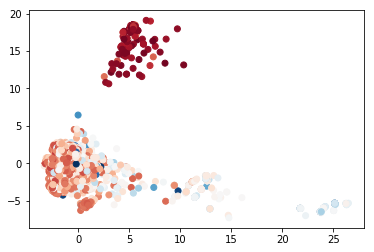

```python
pca_df = pd.DataFrame(data=pca_data, columns=("1st", "2nd", "label"))
plt.scatter(pca_df['1st'],pca_df['2nd'], c=pca_df['label'], cmap="RdBu")
plt.show()
```

From the above plot it is clear that reducing the dimention to 2, one cluster is separable from others. It might be a useful feature.

Experiment with Correlation among features

```python
#taking corr 0.25 as threshold on experimental grounds
dic={}
for i in X_train_num.columns:
    if i!='y':
        if train_df_modified[i].corr(Y_train)>0.25 or train_df_modified[i].corr(Y_train)<-0.25:
            dic[i]=train_df_modified[i].corr(Y_train)
print("Important Features with there respective correlations are ",'\n','---------------------------------------------------------','\n',dic)
```

```
Important Features with there respective correlations are
 ---------------------------------------------------------
 {'X28': -0.2615483878531125, 'X29': -0.39798467184249353, 'X54': -0.39362263688451005, 'X80': -0.2566304628986175, 'X118': 0.29113400781216325, 'X127': -0.5359508861669309, 'X136': 0.39362263688451005, 'X162': -0.380960152680421, 'X166': -0.3469061103890673, 'X178': -0.31054903426087876, 'X185': -0…
```

There are some positive correlations, which seems interesting. Combining such features might give better results.

### Now, Reading and preparing the Test Data:

```python
test_df = pd.read_csv('test.csv')
print("Number of data points:",test_df.shape[0])
```

```
Number of data points: 4209
```

```python
test_df.head(2)
```

|  | ID | X0 | X1 | X2 | X3 | X4 | X5 | X6 | X8 | X10 | ... | X375 | X376 | X377 | X378 | X379 | X380 | X382 | X383 | X384 | X385 |
| --- | --- | --- | --- | --- | --- | --- | --- | --- | --- | --- | --- | --- | --- | --- | --- | --- | --- | --- | --- | --- | --- |
| 0 | 1 | az | v | n | f | d | t | a | w | 0 | ... | 0 | 0 | 0 | 1 | 0 | 0 | 0 | 0 | 0 | 0 |
| 1 | 2 | t | b | ai | a | d | b | g | y | 0 | ... | 0 | 0 | 1 | 0 | 0 | 0 | 0 | 0 | 0 | 0 |

2 rows × 377 columns

```python
ID = test_df['ID']
```

```python
#test_df.drop(['ID'],axis=1,inplace=True)
X_test = test_df
```

```python
test_df.info()
```

```
<class 'pandas.core.frame.DataFrame'>
RangeIndex: 4209 entries, 0 to 4208
Columns: 377 entries, ID to X385
dtypes: int64(369), object(8)
memory usage: 12.1+ MB
```

```python
test_df_modified= test_df.drop(rem_cols,axis=1)
test_df_modified.shape
```

```
(4209, 318)
```

```python
X_test_cat = test_df_modified.loc[:,test_df.dtypes==np.object]
```

```python
X_test_cat.shape
```

```
(4209, 7)
```

```python
X_test_num = test_df_modified.loc[:,test_df.dtypes==np.int64]
```

```python
X_test_num.shape
```

```
(4209, 311)
```

```python
### Pre-processing of features
```

### Label Encoding Section

```python
vocab = []
vocab.extend(X_train_cat.values.ravel())
vocab.extend(X_test_cat.values.ravel())
```

```python
vectorizer=LabelEncoder()
vectorizer.fit(vocab)
#Using Label Encoding
X_train_x0_le=vectorizer.transform(X_train['X0'].values).reshape(len(X_train),1)
X_test_x0_le=vectorizer.transform(X_test['X0'].values).reshape(len(X_test),1)
X_train_x1_le=vectorizer.transform(X_train['X1'].values).reshape(len(X_train),1)
X_test_x1_le=vectorizer.transform(X_test['X1'].values).reshape(len(X_test),1)
X_train_x2_le=vectorizer.transform(X_train['X2'].values).reshape(len(X_train),1)
X_test_x2_le=vectorizer.transform(X_test['X2'].values).reshape(len(X_test),1)
X_train_x3_le=vectorizer.transform(X_train['X3'].values).reshape(len(X_train),1)
X_test_x3_le=vectorizer.transform(X_test['X3'].values).reshape(len(X_test),1)
X_train_x5_le=vectorizer.transform(X_train['X5'].values).reshape(len(X_train),1)
X_test_x5_le=vectorizer.transform(X_test['X5'].values).reshape(len(X_test),1)
X_train_x6_le=vectorizer.transform(X_train['X6'].values).reshape(len(X_train),1)
X_test_x6_le=vectorizer.transform(X_test['X6'].values).reshape(len(X_test),1)
X_train_x8_le=vectorizer.transform(X_train['X8'].values).reshape(len(X_train),1)
X_test_x8_le=vectorizer.transform(X_test['X8'].values).reshape(len(X_test),1)
```

```python
from scipy.sparse import hstack
print('Categorical Label Encoded Matrix:')
X_train_cat_le =np.concatenate((X_train_x0_le,X_train_x1_le,X_train_x2_le,X_train_x3_le,X_train_x5_le,X_train_x6_le,X_train_x8_le),axis=1)
print(X_train_cat_le.shape)
X_test_cat_le = np.concatenate((X_test_x0_le,X_test_x1_le,X_test_x2_le,X_test_x3_le,X_test_x5_le,X_test_x6_le,X_test_x8_le),axis=1)
print(X_test_cat_le.shape)
```

```
Categorical Label Encoded Matrix:
(4194, 7)
(4209, 7)
```

```python
normalizer=Normalizer()
#Initializing the normalizer to normalize the train and test data
X_train_cat_le=normalizer.fit_transform(X_train_cat_le)
X_test_cat_le=normalizer.transform(X_test_cat_le)
```

```python
from scipy.sparse import hstack
print('Final Matrix:')
X_train_le = hstack((X_train_cat_le,X_train_num)).tocsr()
print(X_train_le.shape)
X_test_le = hstack((X_test_cat_le,X_test_num)).tocsr()
print(X_test_le.shape)
```

```
Final Matrix:
(4194, 318)
(4209, 318)
```

Adding PCA Transformed as Features

```python
standardized_data_tr = StandardScaler().fit_transform(X_train_num)
standardized_data_te = StandardScaler().fit_transform(X_test_num)
print(standardized_data_tr.shape)
print(standardized_data_te.shape)
pca = PCA()
pca.n_components = 6 #Chosen on experimental grounds
pca_data_tr = pca.fit_transform(standardized_data_tr)
pca_data_te = pca.transform(standardized_data_te)
print('After Transformation:')
print(pca_data_tr.shape)
print(pca_data_te.shape)
```

```
(4194, 311)
(4209, 311)
After Transformation:
(4194, 6)
(4209, 6)
```

```python
train_df_modified_pca = train_df_modified.copy()
train_df_modified_pca["PCA_1"] = pca_data_tr[:,0]
train_df_modified_pca["PCA_2"] = pca_data_tr[:,1]
train_df_modified_pca["PCA_3"] = pca_data_tr[:,2]
train_df_modified_pca["PCA_4"] = pca_data_tr[:,3]
train_df_modified_pca["PCA_5"] = pca_data_tr[:,4]
train_df_modified_pca["PCA_6"] = pca_data_tr[:,5]
test_df_modified_pca = test_df_modified.copy()
test_df_modified_pca["PCA_1"] = pca_data_te[:,0]
test_df_modified_pca["PCA_2"] = pca_data_te[:,1]
test_df_modified_pca["PCA_3"] = pca_data_te[:,2]
test_df_modified_pca["PCA_4"] = pca_data_te[:,3]
test_df_modified_pca["PCA_5"] = pca_data_te[:,4]
test_df_modified_pca["PCA_6"] = pca_data_te[:,5]
```

Label Encoding and PCA

```python
from scipy.sparse import hstack
print('Final PCA Matrix:')
X_train_le_PCA = hstack((X_train_le,pca_data_tr)).tocsr()
print(X_train_le_PCA.shape)
X_test_le_PCA = hstack((X_test_le,pca_data_te)).tocsr()
X_test_le_PCA = hstack((X_test_le,pca_data_te)).tocsr()
print(X_test_le_PCA.shape)
```

```
Final PCA Matrix:
(4194, 324)
(4209, 324)
```

```python
train_df_modified['X314_plus_X315'] = train_df_modified.apply(lambda row: row.X314 + row.X315, axis=1)
test_df_modified['X314_plus_X315'] = test_df_modified.apply(lambda row: row.X314 + row.X315, axis=1)
train_df_modified_pca['X314_plus_X315'] = train_df_modified.apply(lambda row: row.X314 + row.X315,axis=1)
test_df_modified_pca['X314_plus_X315'] = test_df_modified.apply(lambda row: row.X314 + row.X315, axis=1)
```

```python
print("Correalation between X314_plus_X315 and y is :",Y_train.corr(train_df_modified['X314_plus_X315']))
```

```
Correalation between X314_plus_X315 and y is : 0.6990819224017307
```

Taking X118 , X314 and X315:

```python
train_df_modified['X118_plus_X314_plus_X315'] = train_df_modified.apply(lambda row: row.X118 + row.X314 + row.X315, axis=1)
test_df_modified['X118_plus_X314_plus_X315'] = test_df_modified.apply(lambda row: row.X118 + row.X314 + row.X315, axis=1)
train_df_modified_pca['X118_plus_X314_plus_X315'] = train_df_modified.apply(lambda row: row.X118 +row.X314 + row.X315, axis=1)
test_df_modified_pca['X118_plus_X314_plus_X315'] = test_df_modified.apply(lambda row: row.X118 + row.X314 + row.X315, axis=1)
```

```python
print("Correalation between X118_plus_X314_plus_X315 and y is : ",Y_train.corr(train_df_modified['X118_plus_X314_plus_X315']))
```

```
Correalation between X118_plus_X314_plus_X315 and y is :  0.6837266223799761
```

Taking X118 and X263

```python
train_df_modified['X118_plus_X263'] = train_df_modified.apply(lambda row: row.X118 + row.X263, axis=1)
test_df_modified['X118_plus_X263'] = test_df_modified.apply(lambda row: row.X118 + row.X263, axis=1)
train_df_modified_pca['X118_plus_X263'] = train_df_modified.apply(lambda row: row.X118 + row.X263,axis=1)
train_df_modified_pca['X118_plus_X263'] = train_df_modified.apply(lambda row: row.X118 + row.X263,axis=1)
test_df_modified_pca['X118_plus_X263'] = test_df_modified.apply(lambda row: row.X118 + row.X263, axis=1)
```

```python
print("Correalation between X118_plus_X263 and y is :",Y_train.corr(train_df_modified['X118_plus_X263']))
```

```
Correalation between X118_plus_X263 and y is : 0.3864652751823678
```

Taking X29, X118 and X263

```python
train_df_modified['X29_plus_X118_plus_X263'] = train_df_modified.apply(lambda row: row.X29 + row.X118 + row.X263, axis=1)
test_df_modified['X29_plus_X118_plus_X263'] = test_df_modified.apply(lambda row: row.X29 + row.X118+ row.X263, axis=1)
train_df_modified_pca['X29_plus_X118_plus_X263'] = train_df_modified.apply(lambda row: row.X29 + row.X118 + row.X263, axis=1)
test_df_modified_pca['X29_plus_X118_plus_X263'] = test_df_modified.apply(lambda row: row.X29 + row.X118 + row.X263, axis=1)
```

```python
print("Correalation between X29_plus_X118_plus_X263 and y is : ",Y_train.corr(train_df_modified['X29_plus_X118_plus_X263']))
```

```
Correalation between X29_plus_X118_plus_X263 and y is :  0.2911340078121632
```

Now Adding these features to the label encoded features:

```python
from scipy.sparse import hstack
print('Final Matrix:')
X_train_le_corr = hstack((X_train_le,train_df_modified['X314_plus_X315'].values.reshape(-1,1),train_df_modified['X118_plus_X314_plus_X315'].values.reshape(-1,1),train_df_modified['X118_plus_X263'].values.reshape(-1,1),train_df_modified['X29_plus_X118_plus_X263'].values.reshape(-1,1))).tocsr()
print(X_train_le_corr.shape)
X_test_le_corr = hstack((X_test_le,test_df_modified['X314_plus_X315'].values.reshape(-1,1),test_df_modified['X118_plus_X314_plus_X315'].values.reshape(-1,1),test_df_modified['X118_plus_X263'].values.reshape(-1,1),test_df_modified['X29_plus_X118_plus_X263'].values.reshape(-1,1))).tocsr()
print(X_test_le_corr.shape)
```

```
Final Matrix:
(4194, 322)
(4209, 322)
```

Now Adding these features to the label encoded + PCA features: (Creating DF ~~~~ X_train_le_PCA_corr)

```python
from scipy.sparse import hstack
print('Final PCA Matrix:')
X_train_le_PCA_corr = hstack((X_train_le_PCA,train_df_modified['X314_plus_X315'].values.reshape(-1,1),train_df_modified['X118_plus_X314_plus_X315'].values.reshape(-1,1),train_df_modified['X118_plus_X263'].values.reshape(-1,1),train_df_modified['X29_plus_X118_plus_X263'].values.reshape(-1,1))).tocsr()
print(X_train_le_PCA_corr.shape)
X_test_le_PCA_corr = hstack((X_test_le_PCA,test_df_modified['X314_plus_X315'].values.reshape(-1,1),test_df_modified['X118_plus_X314_plus_X315'].values.reshape(-1,1),test_df_modified['X118_plus_X263'].values.reshape(-1,1),test_df_modified['X29_plus_X118_plus_X263'].values.reshape(-1,1))).tocsr()
print(X_test_le_PCA_corr.shape)
```

```
Final PCA Matrix:
(4194, 328)
(4209, 328)
```

### Moddeling Section With xgboost :

XG Boost with Label + Correlation Features:

```python
import xgboost as xgb
from xgboost import XGBRegressor
```

```python
neigh=XGBRegressor(random_state=42, n_jobs=-1)
parameters = {'learning_rate':[0.001,0.01,0.05,0.1,1],
              'n_estimators':[100,150,200,350,400,500],
              'max_depth':[2,3,5,7,8,10],
              'colsample_bytree':[0.1,0.2,0.3,0.4,0.5,0.7,0.8,1],
              'max_features': [.95],
              'subsample':[0.2,0.3,0.5,0.6,0.7,0.8,1],
              'gamma':[1e-2,1e-3,0,0.1,0.01,0.5,1],
               'reg_alpha':[1e-5,1e-3,1e-1,1,1e1]}
clf=RandomizedSearchCV(neigh,parameters,cv=10,scoring='r2',return_train_score=True,n_jobs=-1,verbose=5)
clf.fit(X_train_le_corr,Y_train)
```

```
Fitting 10 folds for each of 10 candidates, totalling 100 fits
```

```
[Parallel(n_jobs=-1)]: Done  10 tasks      | elapsed:   30.2s
[Parallel(n_jobs=-1)]: Done  64 tasks      | elapsed:  1.9min
[Parallel(n_jobs=-1)]: Done 100 out of 100 | elapsed:  2.7min finished
```

[output not shown]

```
RandomizedSearchCV(cv=10, error_score='raise',
          estimator=XGBRegressor(base_score=None, booster=None, colsample_bylevel=None,
       colsample_bynode=None, colsample_bytree=None, gamma=None,
       gpu_id=None, importance_type='gain', interaction_constraints=None,
       learning_rate=None, max_delta_step=None, max_depth=None,
       min_child_we..._pos_weight=None, subsample=None,
       tree_method=None, validate_parameters=None, verbosity=None),
          fit_params=None, iid=True, n_iter=10, n_jobs=-1,
          param_distributions={'learning_rate': [0.001, 0.01, 0.05, 0.1, 1], 'n_estimators': [100, 150, 200, 350, 400, 500], 'max_depth': [2, 3, 5, 7, 8, 10], 'colsample_bytree': [0.1, 0.2, 0.3, 0.4, 0.5, 0.7, 0.8, 1], 'max_features': [0.95], 'subsample': [0.2, 0.3, 0.5, 0.6, 0.7, 0.8, 1], 'gamma': …
          pre_dispatch='2*n_jobs', random_state=None, refit=True,
          return_train_score=True, scoring='r2', verbose=5)
```

```python
results=pd.DataFrame.from_dict(clf.cv_results_)
train_r2=results['mean_train_score']
cv_r2=results['mean_test_score']
```

```python
for i,j in zip(train_r2,cv_r2):
    print("Train:{} CV:{}".format(i,j))
```

```
Train:0.5604337174359149 CV:0.5583422873838306
Train:0.7070019551707152 CV:0.6134510940529241
Train:0.6679146245021554 CV:0.5168733940839195
Train:0.9805319007572353 CV:0.549772235910551
Train:0.9630341566129802 CV:0.4934212351492899
Train:0.7457731261989661 CV:0.6086768494037634
Train:0.9436056898824713 CV:0.5960582048295662
Train:0.6488464580122062 CV:0.5915206805624791
Train:-0.6526744887120615 CV:-0.655483391512605
Train:-46.35770523536752 CV:-46.860767828737075
```

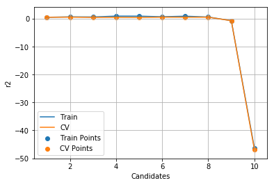

```
The Best Score 0.6134510940529241
```

```python
candidates = list(range(1,11))
plt.plot(candidates,train_r2,label='Train')
plt.plot(candidates,cv_r2,label='CV')
plt.scatter(candidates,train_r2,label='Train Points')
plt.scatter(candidates,cv_r2,label='CV Points')
plt.legend()
plt.xlabel("Candidates")
plt.ylabel("r2")
plt.grid()
plt.show()
print("The Best Score",clf.best_score_)
```

```python
clf.best_estimator_
```

```
XGBRegressor(base_score=0.5, booster='gbtree', colsample_bylevel=1,
       colsample_bynode=1, colsample_bytree=0.7, gamma=0.01, gpu_id=-1,
       importance_type='gain', interaction_constraints='',
       learning_rate=0.05, max_delta_step=0, max_depth=7,
       max_features=0.95, min_child_weight=1, missing=nan,
       monotone_constraints='()', n_estimators=100, n_jobs=-1,
       num_parallel_tree=1, objective='reg:squarederror', random_state=42,
       reg_alpha=10.0, reg_lambda=1, scale_pos_weight=1, subsample=0.3,
       tree_method='exact', validate_parameters=1, verbosity=None)
```

```python
model_xgb_label = XGBRegressor(base_score=0.5, booster='gbtree', colsample_bylevel=1,colsample_bynode=1, colsample_bytree=1, gamma=0.1,
                               importance_type='gain', learning_rate=0.05, max_delta_step=0,max_depth=2, max_features=0.95, min_child_weight=1, missing=None,
                               n_estimators=350, n_jobs=-1, nthread=None, objective='reg:linear',random_state=42, reg_alpha=1, reg_lambda=1, scale_pos_weight=1,
                            seed=None, silent=None, subsample=0.7, verbosity=1)
model_xgb_label.fit(X_train_le_corr,Y_train)
```

[output not shown]

```
XGBRegressor(base_score=0.5, booster='gbtree', colsample_bylevel=1,
       colsample_bynode=1, colsample_bytree=1, gamma=0.1, gpu_id=-1,
       importance_type='gain', interaction_constraints='',
       learning_rate=0.05, max_delta_step=0, max_depth=2,
       max_features=0.95, min_child_weight=1, missing=None,
       monotone_constraints='()', n_estimators=350, n_jobs=-1, nthread=-1,
       num_parallel_tree=1, objective='reg:linear', random_state=42,
       reg_alpha=1, reg_lambda=1, scale_pos_weight=1, seed=42, silent=None,
       subsample=0.7, tree_method='exact', validate_parameters=1,
       verbosity=1)
```

```python
pred_test_xgb_label = model_xgb_label.predict(X_test_le_corr)
```

```python
data={'ID':[i for i in ID],'y':[j for j in pred_test_xgb_label]}
data = pd.DataFrame(data)
data.to_csv("submission_xgb_label.csv", index=False)
```

XG Boost with Label + Correlation Features + PCA: (This should gives better accuracy than before as we added PCA)

```python
neigh=XGBRegressor(random_state=42, n_jobs=-1)
parameters = {'learning_rate':[0.001,0.01,0.05,0.1,1],
             'n_estimators':[100,150,200,350,400,500],
            'max_depth':[2,3,5,7,8,10],
            'colsample_bytree':[0.1,0.2,0.3,0.4,0.5,0.7,0.8,1],
            'max_features': [.95],
            'subsample':[0.2,0.3,0.5,0.6,0.7,0.8,1],
            'gamma':[1e-2,1e-3,0,0.1,0.01,0.5,1],
            'reg_alpha':[1e-5,1e-3,1e-1,1,1e1]}
clf=RandomizedSearchCV(neigh,parameters,cv=10,scoring='r2',return_train_score=True,n_jobs=-1,verbose=5)#Uisng k-fold cross validation with k=5
clf.fit(X_train_le_PCA_corr,Y_train)
```

```
Fitting 10 folds for each of 10 candidates, totalling 100 fits
```

```
[Parallel(n_jobs=-1)]: Done  10 tasks      | elapsed:   18.0s
[Parallel(n_jobs=-1)]: Done  64 tasks      | elapsed:  1.2min
[Parallel(n_jobs=-1)]: Done 100 out of 100 | elapsed:  1.6min finished
```

[output not shown]

```
RandomizedSearchCV(cv=10, error_score='raise',
          estimator=XGBRegressor(base_score=None, booster=None, colsample_bylevel=None,
       colsample_bynode=None, colsample_bytree=None, gamma=None,
       gpu_id=None, importance_type='gain', interaction_constraints=None,
       learning_rate=None, max_delta_step=None, max_depth=None,
       min_child_we..._pos_weight=None, subsample=None,
       tree_method=None, validate_parameters=None, verbosity=None),
          fit_params=None, iid=True, n_iter=10, n_jobs=-1,
          param_distributions={'learning_rate': [0.001, 0.01, 0.05, 0.1, 1], 'n_estimators': [100, 150, 200, 350, 400, 500], 'max_depth': [2, 3, 5, 7, 8, 10], 'colsample_bytree': [0.1, 0.2, 0.3, 0.4, 0.5, 0.7, 0.8, 1], 'max_features': [0.95], 'subsample': [0.2, 0.3, 0.5, 0.6, 0.7, 0.8, 1], 'gamma': …
          pre_dispatch='2*n_jobs', random_state=None, refit=True,
          return_train_score=True, scoring='r2', verbose=5)
```

```python
results=pd.DataFrame.from_dict(clf.cv_results_)
train_r2=results['mean_train_score']
cv_r2=results['mean_test_score']
```

```python
for i,j in zip(train_r2,cv_r2):
    print("Train:{} CV:{}".format(i,j))
```

```
Train:-56.7544981549829 CV:-57.37789921644834
Train:0.9316117328985982 CV:0.20892931053962013
Train:-1122932.5383997844 CV:-3251661.9923554286
Train:0.6402168037202529 CV:0.6222334374481472
Train:-2.8313458240629075 CV:-2.8474355043726236
Train:-0.17504035264119536 CV:-4.838676330332175
Train:0.8393319197701459 CV:0.5806753858396922
Train:0.5691052443123084 CV:0.34215418043317386
Train:0.6013988249137707 CV:0.5953973342289242
Train:0.8988503918905149 CV:0.5756353774708453
```

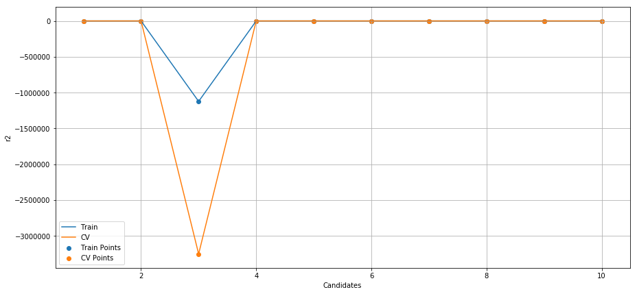

```
The Best Score 0.6222334374481472
```

```python
candidates = list(range(1,11))
plt.figure(figsize=(15,7))
plt.plot(candidates,train_r2,label='Train')
plt.plot(candidates,cv_r2,label='CV')
plt.scatter(candidates,train_r2,label='Train Points')
plt.scatter(candidates,cv_r2,label='CV Points')
plt.legend()
plt.xlabel("Candidates")
plt.ylabel("r2")
plt.grid()
plt.show()
print("The Best Score",clf.best_score_)
```

### Here we have achieved a bit more accuarcy with xgboost applied with Label encoded and PCA components : 62.23%

```python
clf.best_estimator_
```

```
XGBRegressor(base_score=0.5, booster='gbtree', colsample_bylevel=1,
       colsample_bynode=1, colsample_bytree=0.8, gamma=0.01, gpu_id=-1,
       importance_type='gain', interaction_constraints='',
       learning_rate=0.05, max_delta_step=0, max_depth=2,
       max_features=0.95, min_child_weight=1, missing=nan,
       monotone_constraints='()', n_estimators=100, n_jobs=-1,
       num_parallel_tree=1, objective='reg:squarederror', random_state=42,
       reg_alpha=1e-05, reg_lambda=1, scale_pos_weight=1, subsample=0.7,
       tree_method='exact', validate_parameters=1, verbosity=None)
```